# Лабораторная работа №10

Текстовой редактор vi

Липатников Андрей

1032253853@rudn.ru

Российский университет дружбы народов

2026.10.08

# Информация

## Докладчик

- Липатников Андрей
- Студент НКАбд-04-25
- Российский университет дружбы народов
- 1032253853@rudn.ru

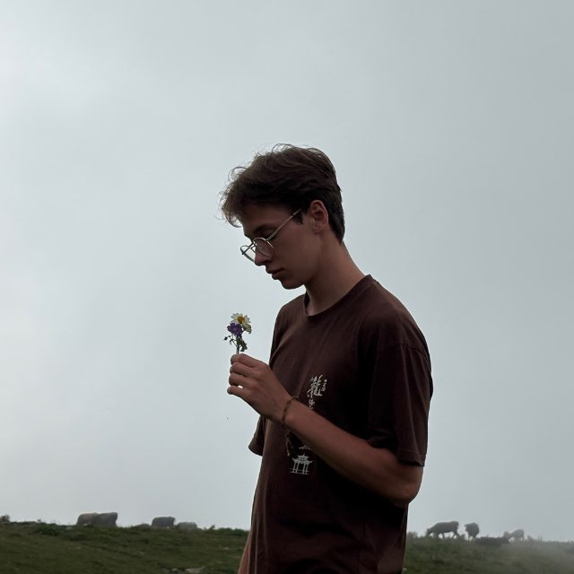

# Вводная часть

## Актуальность

- vi установлен по умолчанию практически во всех дистрибутивах Linux
- присутствует даже в минимальных системах без графики
- обязательный навык администратора при работе через ssh
- модальная модель vi — основа vim и современных редакторов

## Объект и предмет исследования

- **Объект**: текстовый редактор vi
- **Предмет**: режимы работы vi, команды навигации и редактирования, создание и правка скрипта hello.sh

## Цели и задачи

- **Цель**: познакомиться с операционной системой Linux; получить практические навыки работы с редактором vi, установленным по умолчанию практически во всех дистрибутивах.
- **Задачи**:
  - изучить три режима работы vi
  - создать файл hello.sh средствами vi
  - сделать файл исполняемым
  - отредактировать hello.sh командами vi
  - освоить команды навигации и редактирования

## Материалы и методы

# Содержание исследования

## Режимы работы vi

- **Командный режим** — навигация и команды редактирования
- **Режим вставки** — ввод текста
- **Режим последней строки** — запись в файл, выход, настройки

Возврат в командный — [Esc]

Вход в режим вставки — i, a, I, A, o, O

Вход в режим последней строки — [Shift-:]

Выход — :wq, :q, :q!

## Создание файла hello.sh

- Выполнен переход в каталог лабораторной работы, вызван vi hello.sh
- Нажата i, введён текст скрипта
- Нажата [Esc] — возврат в командный режим
- Выполнено :wq — запись и выход

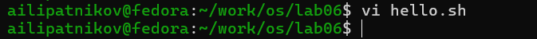

Вызов vi для создания файла hello.sh

## Ввод текста и возврат в командный режим

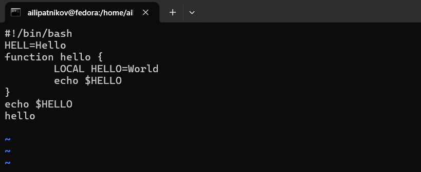

Ввод текста в режиме вставки

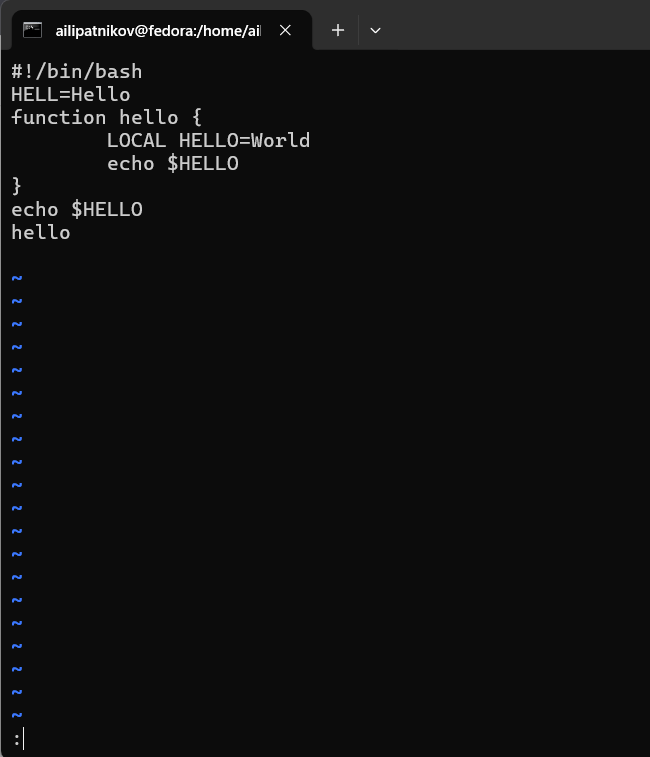

Возврат в командный режим по Esc

## Права на выполнение

- Выполнено chmod +x hello.sh

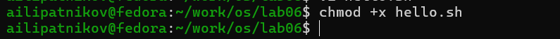

Файл hello.sh сделан исполняемым

## Открытие файла на редактирование

- Выполнено vi hello.sh
- Строка состояния: 9L, 93B

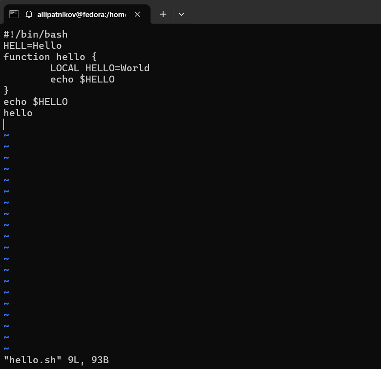

Открытие файла hello.sh в vi

## Замена HELL на HELLO

- Курсор в конец слова HELL второй строки
- Нажата i, введена буква O, нажата [Esc]

## Удаление и вставка слова

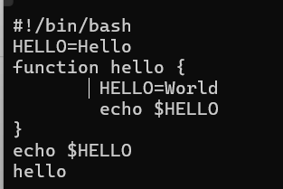

Удаление слова LOCAL командой dw

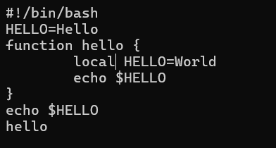

Вставка слова local

## Вставка и удаление строки

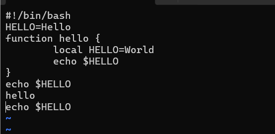

Добавление строки echo $HELLO командой o

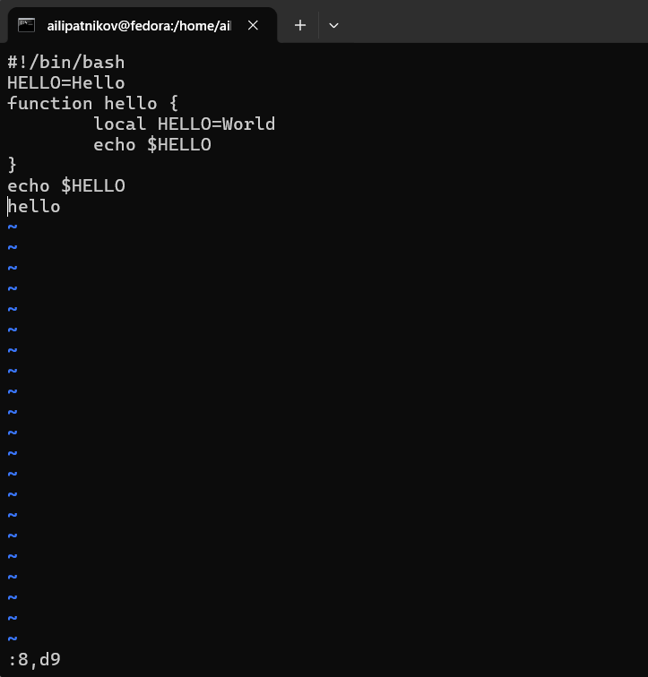

## Отмена удаления

- Команда u вернула удалённую строку

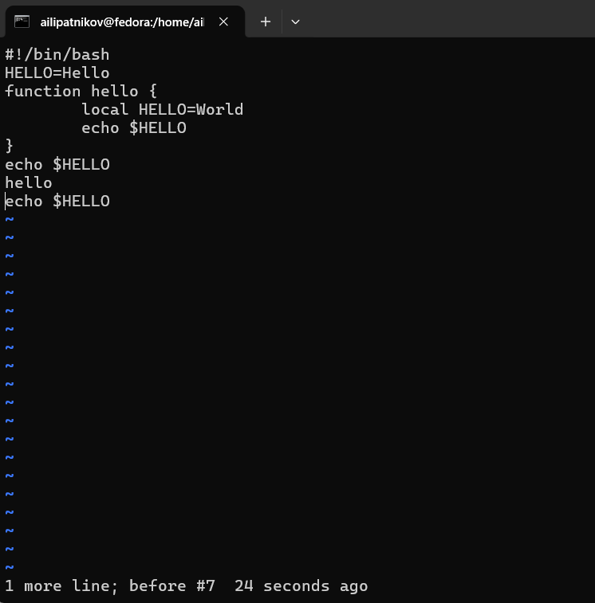

Отмена последнего действия командой u

## Сохранение изменений и выход

- Выполнено :wq в режиме последней строки

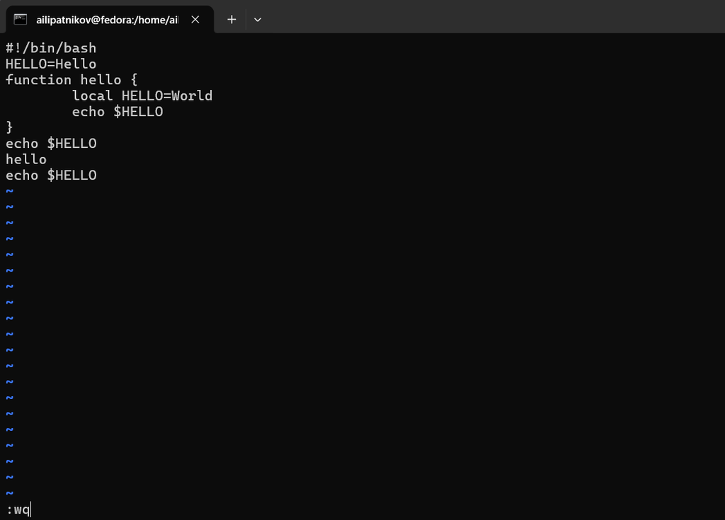

Запись изменений и выход :wq

# Результаты

## Полученные результаты

Таблица 1: Сводка результатов

| Действие | Команды vi | Результат |
| --- | --- | --- |
| Создание файла | `vi hello.sh`, `i`, `[Esc]`, `:wq` | Файл создан, сохранён |
| Права | `chmod +x hello.sh` | Файл исполняемый |
| Правка | `i`, `dw`, `o`, `dd`, `u`, `:wq` | Файл отредактирован |
| Контроль | `cat hello.sh` | Содержимое соответствует шагам правки |

## Итоговое содержимое файла

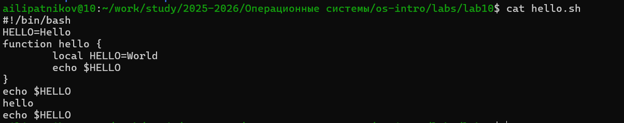

Итоговое содержимое файла hello.sh по команде cat

## Ключевые команды

Таблица 2: Основные команды vi

| Команда | Действие |
| --- | --- |
| `i`, `a`, `o`, `O` | Вход в режим вставки |
| `[Esc]` | Возврат в командный режим |
| `dw` | Удалить слово |
| `dd` | Удалить строку |
| `u` | Отменить последнее действие |
| `:wq` | Сохранить и выйти |
| `:q!` | Выйти без сохранения |

# Заключение

## Главный вывод

vi требует освоения трёх режимов и непривычен после непрерывных редакторов, но окупается скоростью навигации и композиции команд. Навык работы с vi — обязательный минимум администратора Linux, особенно при работе через ssh.